# Spatial Point Patterns

Ripley’s K Function

Yang Li

2026-05-20

# First-order vs Second-order Structure

Spatial point patterns can be described using first-order and second-order properties.

### First-order structure

First-order structure describes the spatial variation in point density.

It is usually described by the intensity function $\lambda(u)$, i.e., the expected number of points per unit area near location $u$.

### Second-order structure

Second-order structure describes **interaction** between points. It asks questions such as:

- Are points close to each other more often than expected?
- Do points repel each other?
- Is there clustering at certain spatial scales?

# Ripley’s K Function

The **K-function**, often called **Ripley’s K-function**, is a *second-order* summary statistic used to study spatial interaction among points.

The K-function is based on counting neighboring points around each observed point.

For a distance $r$, the K-function measures the expected number of additional points within distance $r$ of a typical point, adjusted for the overall intensity.

- If there are more nearby points than expected under CSR, the pattern may be clustered.
- If there are fewer nearby points than expected, the pattern may be regular or inhibited.

# Definition of the K-function

For a stationary spatial point process with intensity $\lambda$, Ripley’s K-function is defined as

$$K(r) =
\frac{1}{\lambda}
E[\text{number of further points within distance } r \text{ of a typical
point}].$$

- $r$ is the distance scale,
- $\lambda$ is the intensity,
- “further points” means points other than the point being used as the center.

**Properties**

- For CSR, $K(r)=\pi r^2$.
- For clustered spatial point patterns, each event is likely to be surrounded by further events. Therefore, for small values of the distance $r$, $K(r)$ will be relatively large.
- For regular point patterns, each event is likely to be surrounded by empty space. This implies that for small values of $r$, $K(r)$ will be relatively small.

# Estimating the K-function

First let’s define

$$E(r)=E[\text{number of further points within distance } r \text{ of a
typical point}]=\lambda K(r).$$
An edge-corrected estimate of $E(r)$ is

$$\hat{E}(r)=\frac{1}{n}\sum_{i=1}^{n}\sum_{j\neq i}w_{ij}I(d_{ij} \leq r)$$

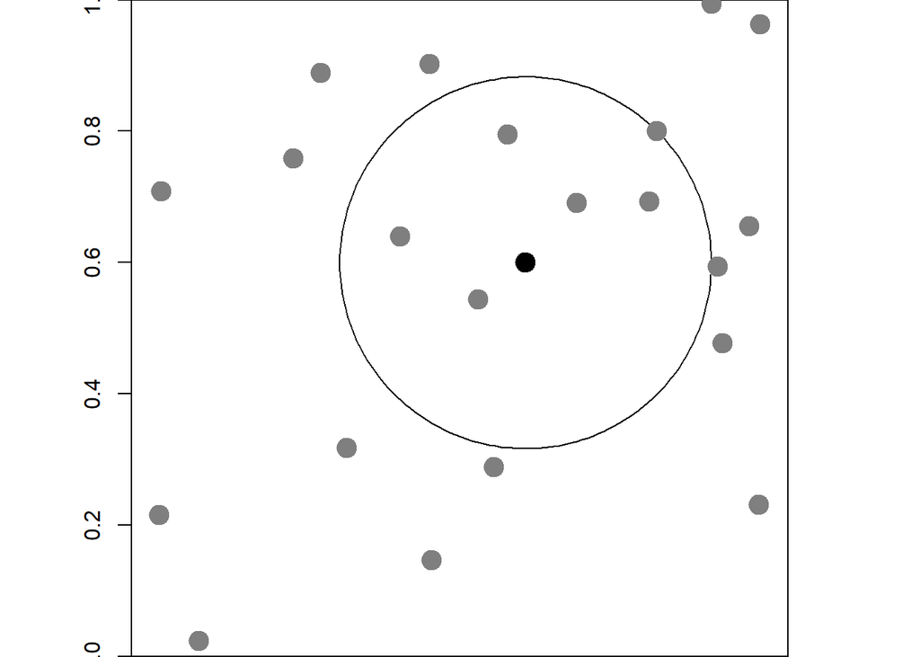

**Edge correction**

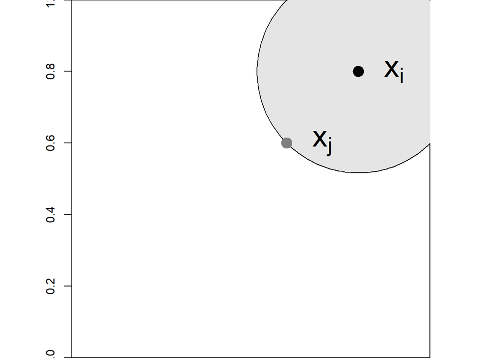

Weights $w_{ij}$ equal to the reciprocal of the proportion of the circle with center $s_i$ and radius $d_{ij}$ which is contained in the study area $A$.

The estimation of $K(r)$ is

$$\hat{K}(r)=\frac{\hat{E}(r)}{\hat{\lambda}}=\frac{|A|}{n^2}\sum_{i=1}^n
\sum_{j \neq i} w_{ij} I(d_{ij} \leq s).$$

# Estimating $K(r)$ in R

The estimation if built in the `Kest()` function in the `spatstat` package in R.

### CSR

```r
suppressPackageStartupMessages({
  library(spatstat)
})

set.seed(1)

X <- rpoispp(lambda = 100)
X
```

```
## Planar point pattern: 93 points
## window: rectangle = [0, 1] x [0, 1] units
```

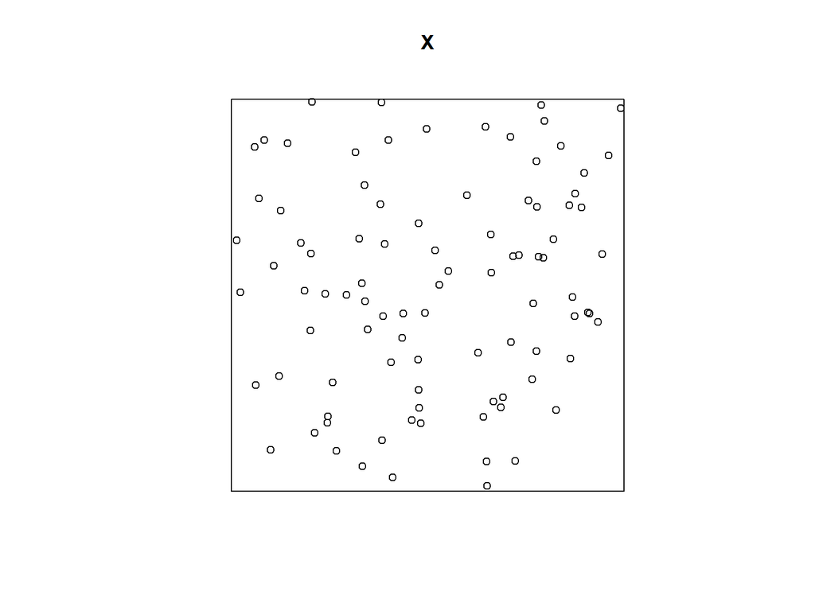

```r
plot(X)
```

#### Estimating $K(r)$

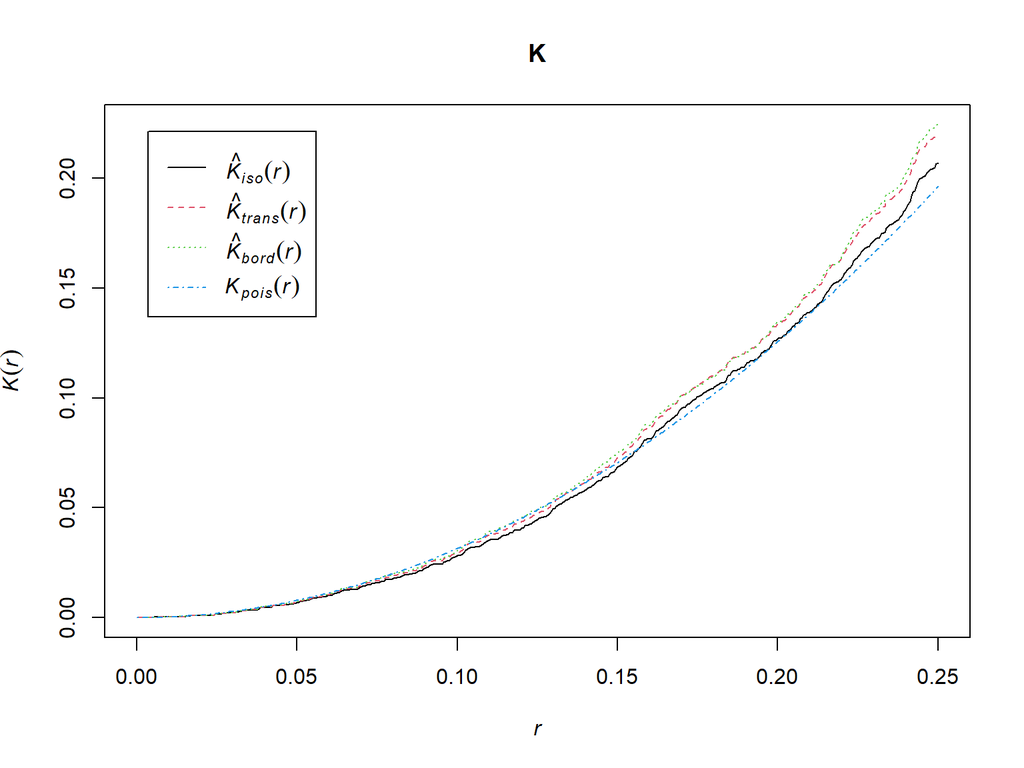

```r
K <- Kest(X)
plot(K)
```

- $K_{\text{iso}}$: isotropic edge-corrected estimate
- $K_{\text{trans}}$: translation edge-corrected estimate
- $K_{\text{bord}}$: border edge-corrected estimate
- $K_{\text{pois}}$: theoretical Poisson/CSR curve $\pi r^2$

#### Interpret the plot

- If $\hat{K}(r) > K_{\text{pois}}(r)$ at a certain $r$, there is clustering/aggregation at scale $r$;
- If $\hat{K}(r) < K_{\text{pois}}(r)$ at a certain $r$, there is regularity/inhibition at scale $r$.

### Aggregated Pattern

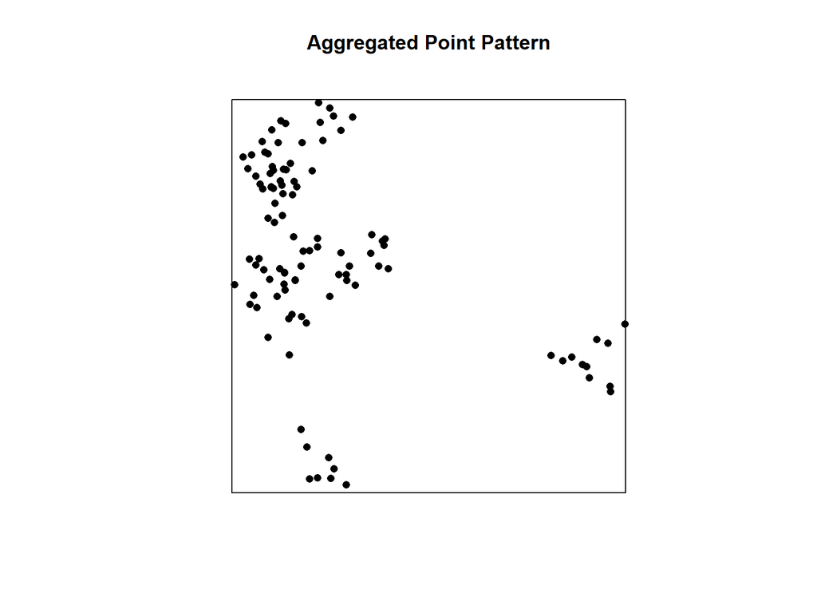

```r
set.seed(1)

cluster_ppp <- rThomas(
  kappa = 10,
  scale = 0.05,
  mu = 10,
  win = owin(c(0, 1), c(0, 1))
)

plot(cluster_ppp, pch = 16, main = "Aggregated Point Pattern")
```

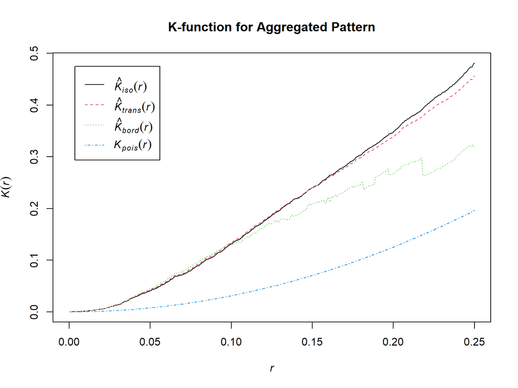

```r
K_cluster <- Kest(cluster_ppp)

plot(K_cluster, main = "K-function for Aggregated Pattern")
```

### Regular Pattern

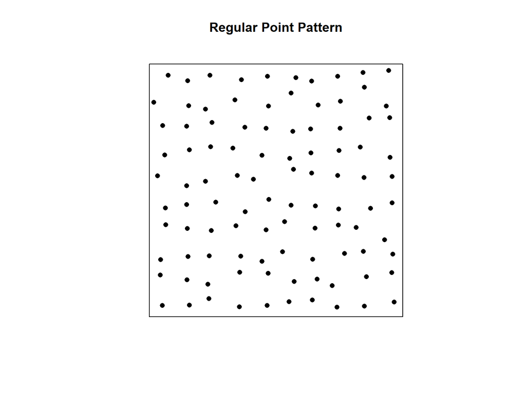

```r
grid_size <- 10

regular_df <- expand.grid(
  x = seq(0.05, 0.95, length.out = grid_size),
  y = seq(0.05, 0.95, length.out = grid_size)
)

regular_df$x <- regular_df$x + rnorm(nrow(regular_df), mean = 0, sd = 0.015)
regular_df$y <- regular_df$y + rnorm(nrow(regular_df), mean = 0, sd = 0.015)
regular_df$pattern <- "Regular"

regular_ppp <- ppp(
  x = regular_df$x,
  y = regular_df$y,
  window = owin(
    xrange = c(0, 1),
    yrange = c(0, 1)
  )
)
plot(regular_ppp, pch = 16, main = "Regular Point Pattern")
```

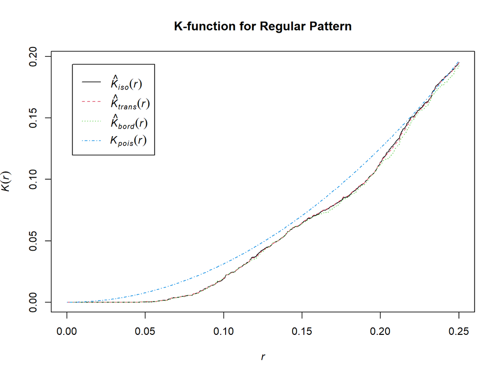

```r
K_regular <- Kest(regular_ppp)

plot(K_regular, main = "K-function for Regular Pattern")
```